# Befolkningsutvecklingen i Säter

Befolkningsutvecklingen i Säter  
- en kort analys

Rapporten är skapad av Samhällsanalys, Region Dalarna  
Senast uppdaterad: 2025-03-25

# Sammanfattning

Syftet med den här korta analysen är att undersöka Säters befolkningsutveckling. Ett antal viktiga slutsatser sammanfattas här:

- Säters folkmängd minskade för andra året i rad, även om minskningen 2024 var något lägre jämfört med året innan.
- Det föddes något färre barn i Säter 2024, jämfört med åren innan. Detta är i linje med en större trend i samhället, då barnafödandet per kvinna i Sverige 2024 var det lägsta som har uppmätts.
- En stramare nationell migrationspolitik gör att färre invandrar till Sverige än tidigare, vilket även påverkar inflyttningen till Säter. Invandringsöverskottet ökade dock tydligt 2024, vilket sannolikt delvis kan förklaras av att personer födda i Ukraina sedan juni 2024 haft möjlighet att ansöka om att bli folkbokförda i Sverige.
- Många mellan 20 och 29 år flyttade från Säter till andra delar av Sverige under 2024, jämfört med året innan.

För mer info om statistiken, klicka på rutan nedan:

**Mer information om statistiken**

I folkmängden som SCB publicerar ingår personer som är folkbokförda i landet. För att den som flyttar till Sverige ska bli folkbokförd ska personen ha för avsikt och rätt att stanna i Sverige i minst ett år. För personer som inte är medborgare i ett EU-land innebär det att det krävs ett uppehållstillstånd som gäller minst 12 månader för att bli folkbokförd. Till följd av Rysslands invasion av Ukraina den 24 februari 2022 har Europeiska unionen (EU) beslutat att aktivera massflyktsdirektivet, vilket innebär att personer från Ukraina utan individuell prövning ska erbjudas tidsbegränsat uppehålls- och arbetstillstånd inom EU. Personer som får uppehållstillstånd enligt massflyktsdirektivet ska i regel inte bli folkbokförda och ingå i den officiella befolkningsstatistiken. Läs mer här. Sedan juni 2024 har dock personer födda i Ukraina haft möjlighet att ansöka om att bli folkbokförda i Sverige [(SCB)](https://www.scb.se/hitta-statistik/statistik-efter-amne/befolkning-och-levnadsforhallanden/befolkningens-sammansattning-och-utveckling/befolkningsstatistik/pong/statistiknyhet/namnlos/).

Under 2023 inledde Skatteverket ett arbete med att granska registret över folkbokförda. Det förde med sig att SCB avregistrerade flera tusen folkbokförda personer som visade sig inte längre bo i Sverige. I folkbokföringen har dessa registrerats som utvandrade till okänt utvandringsland. Detta arbete fortsatte under 2024. Läs mer [här](https://www.scb.se/pressmeddelande/sverige-gar-mot-lagsta-befolkningsokningen-pa-manga-ar/).

All data som används i rapporten är offentlig och finns under kategorin befolkning i SCB:s [Statistikdatabas](https://www.statistikdatabasen.scb.se/pxweb/sv/ssd/). Där finns även data för exempelvis befolkningsutvecklingen under 2025 på månadsbasis som publiceras löpande, något som inte behandlas i denna rapport.

# 1 Hur har befolkningen förändrats?

I Säter har folkmängden ökat sedan slutet på 1960-talet, från ca 9 900 invånare år 1968 till ungefär 11 200 invånare år 2024. Den största ökningen skedde under 1970- och 1980-talen, då befolkningen ökade mer eller mindre varje år. Därefter skedde en minskning efter finanskrisen på 1990-talet, innan befolkningstillväxten återigen tog fart i mitten på 2010-talet. Under 2024 minskade befolkningen med 20 personer, vilket var en något lägre minskning än året innan.

En viktig orsak till Säter positiva befolkningstillväxt på längre sikt är troligtvis närheten till större städer som Borlänge och Falun. Arbetsmarknaden för personer boende i Säter blir därför större än vad den annars skulle vara, vilket gör kommunen mer attraktiv att bo i.

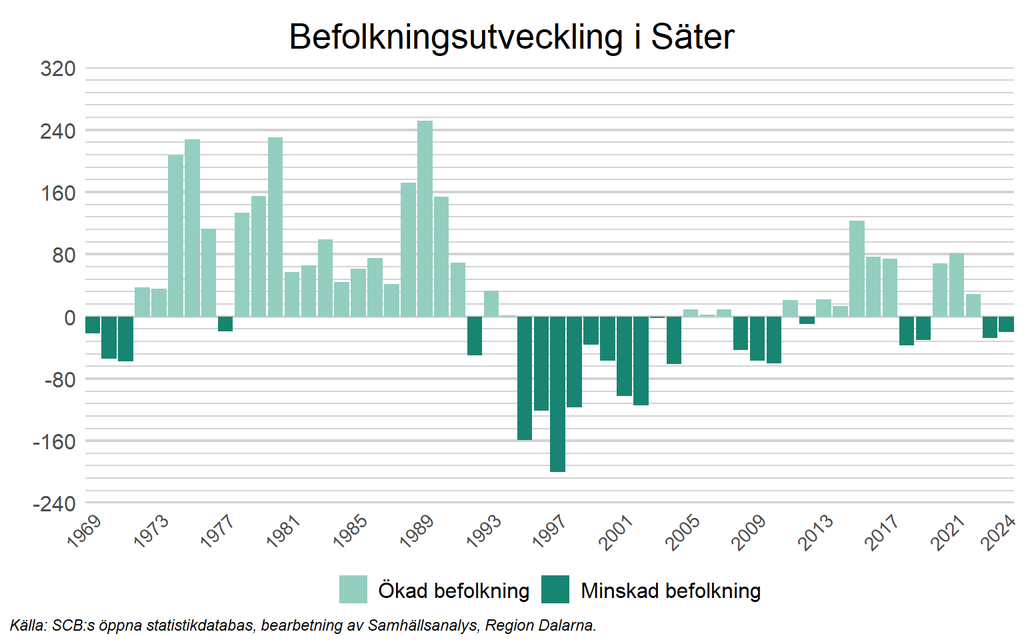

I fortsättningen av denna korta analys delas befolkningsutveckling upp i dess komponenter, födelsenetto, dvs. nettot av födda och döda, och flyttnetto, dvs. nettot av inrikes och utrikes flyttar.

# 2 Födelsenetto

Med undantag för Corona-pandemin, 2020, är en trend att det dör något färre personer i Säter idag än det gjorde längre tillbaka i tiden. På senare år har strax över 100 personer dött årligen i kommunen, att jämföra med ofta mellan 130 och 140 personer per år i slutet av 1970-talet. Detta samtidigt som folkmängden idag är större. Denna utveckling härrör sannolikt till utveckling inom det medicinska området. Befolkningens medelålder ökar över tid och har gjort så länge.

När det gäller antalet födslar är trenden negativ om man jämför med framförallt 1980-talet, men under 2000-talet har antalet födda legat på en relativt stabil nivå. Under slutet av 1980-talet föddes vissa år närmare 200 barn i Säter per år, att jämföra med 95 barn år 2024.

Nettot mellan födda och döda, se de svarta linjerna i diagrammet nedan, har varierat relativt mycket mellan åren. Under 2000-talet har nettot varit positivt under enstaka år, men är för det mesta negativt. På senare år går det att skönja en viss förbättring, då nettot är mindre negativt än det var mellan 2018 och 2020. År 2024 minskade befolkningen med 9 personer till följd av ett negativt födelsenetto, vilket är i linje med åren innan.

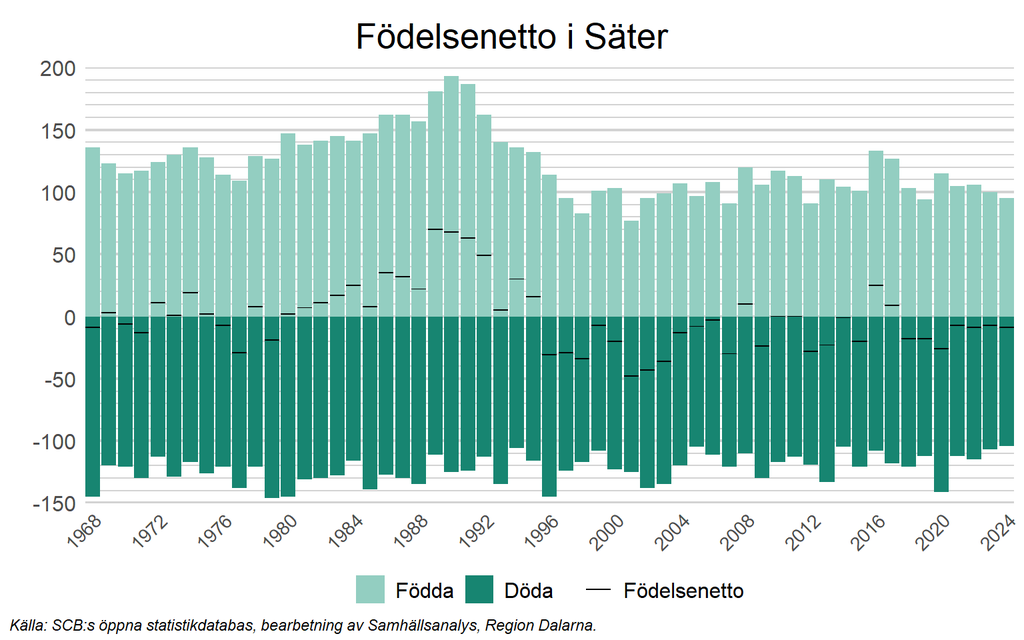

# 3 Flyttnetto

Den andra komponenten som styr befolkningsutvecklingen är det så kallade flyttnettot. Detta kan i sin tur delas upp i två komponenter, inrikes och utrikes flyttar. I det här avsnittet är fokus först på flyttnettot, innan de två komponenterna undersöks.

Nettot mellan antalet personer som flyttar till och från Säter varierar relativt mycket mellan åren, men har varit positivt under stora delar av 2010-talet. Många flyttade till kommunen mellan 2015 och 2017, men även under 2020 och 2021 var inflyttningen stor (netto). År 2024 var flyttnettot negativt (-12 personer), precis som året innan.

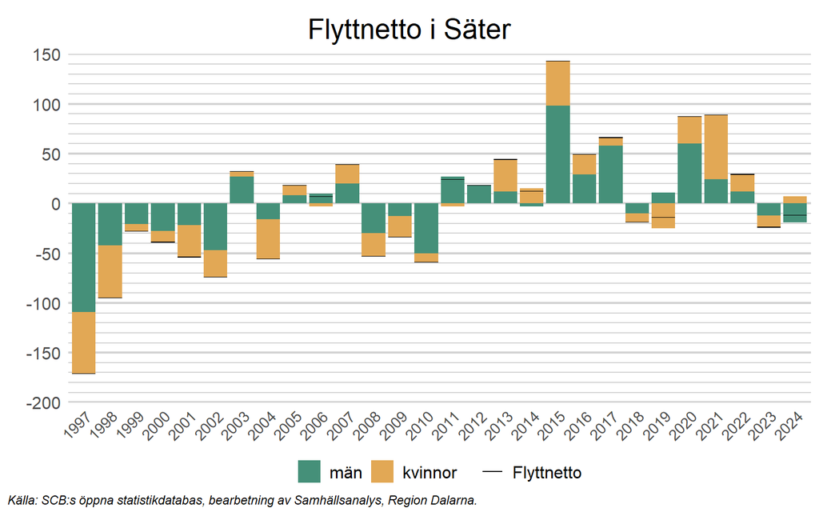

## 3.1 Utrikes flyttnetto

Som vi berörde i föregående avsnitt flyttade många till Säter mellan 2015 och 2017, vilket till stor del kan förklaras av att invandringen då var stor. Det som skiljer Säter från många andra kommuner i Dalarna är att invandringen var som högst redan 2013, för att därefter gradvis minska. Även under 2021 skedde en relativt stor invandring till kommunen. Trenden är dock att invandringen idag är betydligt lägre än den var under flera år på 2010-talet, vilket i första hand har att göra med en tydligt stramare nationell migrationspolitik.

Under 2024 var det utrikes flyttnettot 37 personer, vilket var det största överskottet sedan 2018. Att det utrikes flyttnettot ökade 2024, jämfört med åren innan, beror sannolikt delvis på att personer födda i Ukraina sedan juni 2024 haft möjlighet att ansöka om att bli folkbokförda i Sverige, vilket medförde att antalet personer födda i Ukraina ökade med 15 personer i Säter under 2024 (se [SCB](https://www.statistikdatabasen.scb.se/pxweb/sv/ssd/START__BE__BE0101__BE0101E/FolkmRegFlandK/table/tableViewLayout1/)). Läs mer i den klickbara rutan “mer information om statistiken” ovan.

Viktigt att notera är också att de avregistreringar av utvandrade som Skattemyndigheten påbörjade under 2023 (se informationsrutan under avsnittet introduktion ovan) påverkade utvandringen under såväl 2023 som 2024.

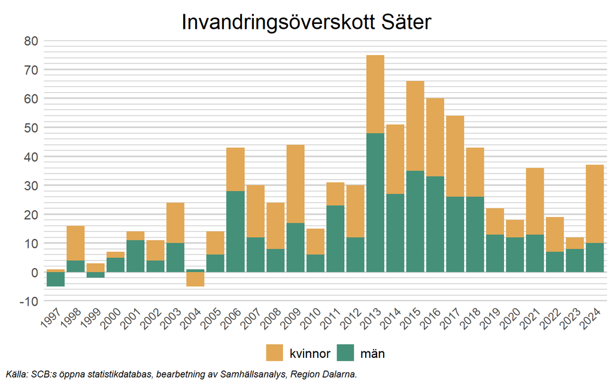

## 3.2 Inrikes flyttnetto

Till skillnad från många andra kommuner i Dalarna har Säter relativt ofta haft ett positivt inrikes flyttnetto på senare år. Visserligen var nettot tydligt negativt under något år mot slutet av 2010-talet, men samtidigt flyttade många till kommunen från andra delar av Sverige under Corona-pandemin och året därefter. Från 2022 och framåt har det dock skett en tydlig minskning av det inrikes flyttnettot, vilket förklarar varför befolkningstillväxten har varit lägre, eller negativ, på sistone. År 2024 flyttade 49 personer netto från kommunen inrikes.

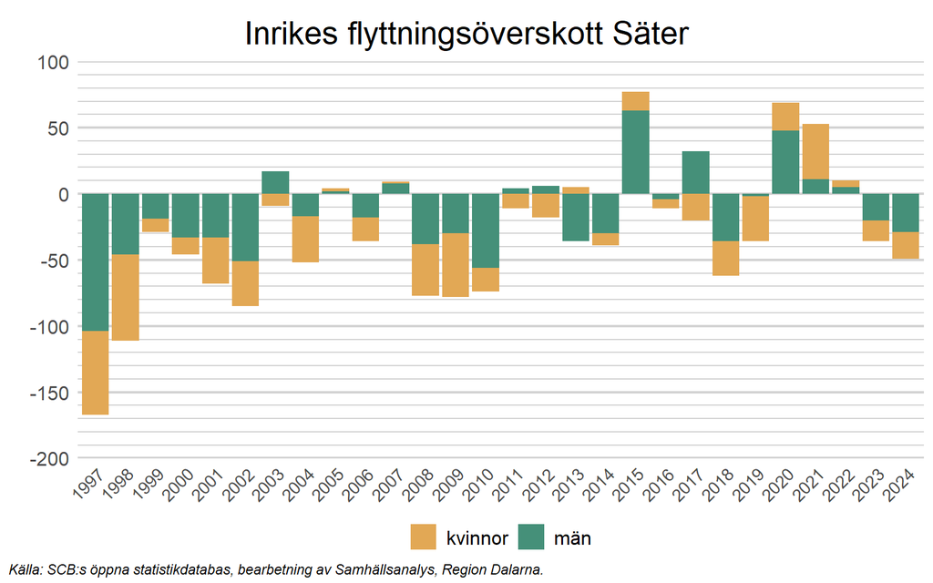

För att bättre förstå vilka som flyttar till och från kommunen inrikes, delas de som flyttar härnäst upp efter ålder. Normalt är personer mest benägna att flytta till en annan ort när de är i 20-års åldern, innan flyttandet gradvis avtar.

### 3.2.1 Uppdelat på ålder

Ett mönster är att det till Säter flyttar fler personer mellan 30 och 39 år än de i samma åldersgrupp som flyttar därifrån, dvs. kommunens invånarantal i den åldersgruppen ökar på grund av inrikes flyttar.

Inom övriga åldergrupper är variationen stor mellan åren och det är svårt att hitta någon större trend, även om det verkar ske en relativt stor utflyttning i gruppen som är 60 år eller äldre.

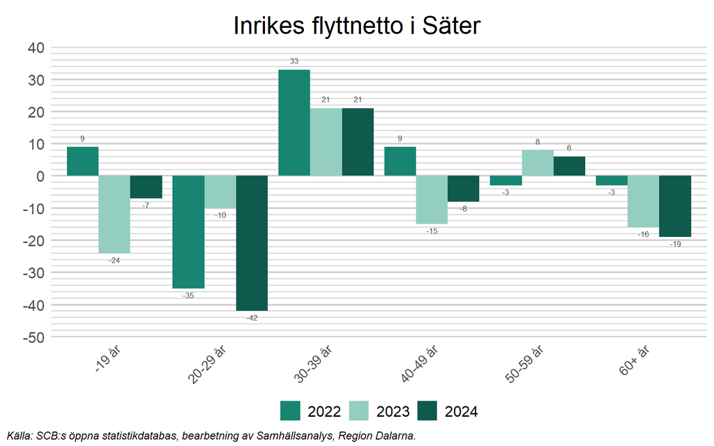

Om fokus enbart läggs på åldersgruppen 20-29 år, blir det tydligt att det under de flesta år flyttar fler unga vuxna från än till kommunen inrikes. Historiskt varierar det inrikes flyttnettot i åldersgruppen mellan åren, vilket exempelvis kan bero på att olika årskullar av barn är olika stora.

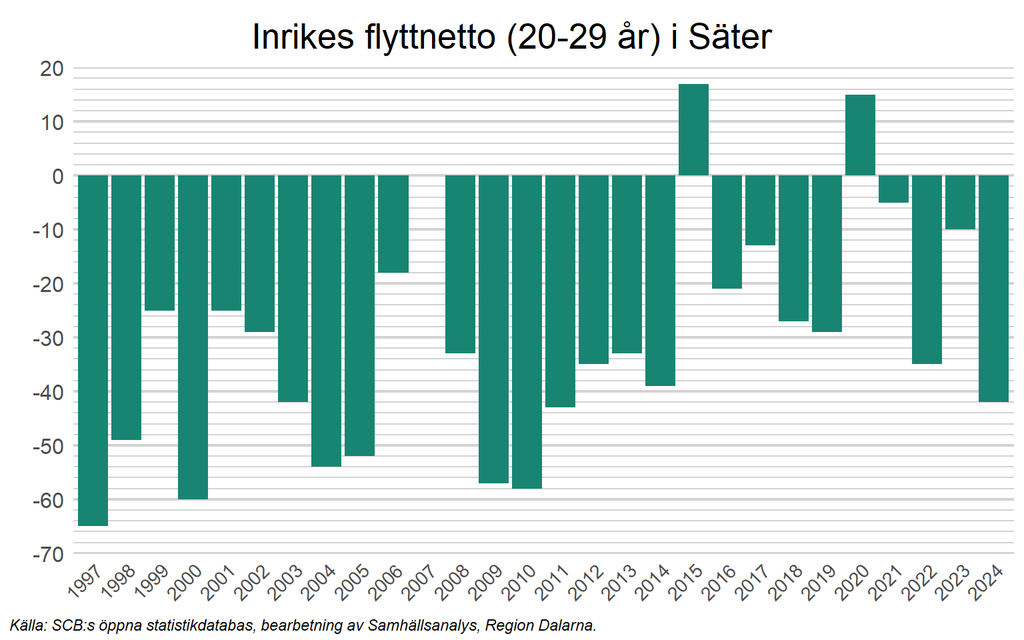

### 3.2.2 Uppdelat på bakgrund

För att ytterligare förtydliga vilka som flyttar till och från Säter inrikes, delas de i detta avsnitt upp efter sin bakgrund, inrikes eller utrikes födda.

En del av de personer som invandrade till Säter under framförallt 2013, verkar ha flyttat därifrån under 2014, då många utrikes födda flyttade till andra delar av Sverige (netto). Även under 2016, 2018 och 2023 skedde en relativt stor utflyttning bland utrikes födda.

Bland inrikes födda är bilden delvis annorlunda. Under 00-talet flyttade ofta många inrikes födda från Säter till andra delar av Sverige, en utveckling som delvis har vänt på senare år. Under såväl 2015, som 2020 och 2021 flyttade mer än 50 personer netto till kommunen inrikes. Efter att ha varit positiv även under 2023, minskade dock inflyttning (netto) av inrikes födda tydligt under 2024.

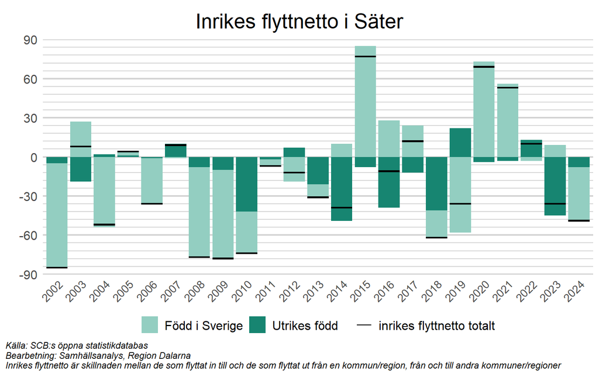

I nästa avsnitt är fokus istället på framtiden. Hur kommer Säters folkmängd att utvecklas fram till 2033?

# 4 Vad händer i framtiden?

För en djupare förståelse runt hur SCB gör befolkningsprognoser, se motsvarande avsnitt i rapporten för hela Dalarnas län. Det viktigaste att ha i åtanke är att ingen hänsyn tas i prognoserna till planerat bostadsbyggande, företagsetableringar eller andra framtida mål och förutsättningar som kommunerna har i sina planer.

I diagrammet nedan visas befolkningsutvecklingen i Säter fram till 2033 uppdelat på åldersgrupper, enligt SCB:s prognos från juni 2024 (se [SCB, 2024](https://www.statistikdatabasen.scb.se/pxweb/sv/ssd/START__BE__BE0401__BE0401A/BefProgRegFakN/)), vilket är den senaste som myndigheten publicerat offentligt på kommunal nivå. Notera att diagrammet kan skilja sig åt jämfört med motsvarande diagram i förra årets rapport. Detta eftersom befolkningen 2033 enligt SCBs prognos jämförs med den faktiska befolkningen vid slutet av 2024 i diagrammet nedan. I förra årets rapport jämfördes prognosen för 2033 med den faktiska befolkningen vid slutet av 2023.

- Säters befolkning prognostiseras att minska med drygt 250 personer till 2033, jämfört med 2024. I SCB:s föregående prognos, som släpptes 2022, prognostiserades en ökning på runt 30 personer fram till 2033, jämfört med 2021 (se [SCB, 2022](https://www.statistikdatabasen.scb.se/pxweb/sv/ssd/START__BE__BE0401__BE0401B/BefProgRegFakN22/table/tableViewLayout1/)).
- Den största minskningen sker i åldergruppen 20-64 år, som prognostiseras minska med ungefär 240 personer.
- I åldergruppen 80+ förväntas befolkning att öka med ungefär 360 personer fram till 2033. Detta hänger sannolikt samman med att den förväntade livslängden fortsätter öka och att den stora gruppen “baby-boomers” börjar komma upp i 80-års åldern.
- Även i åldersgruppen 0-19 år sker en relativt stor minskning av befolkningen, knappt 190 personer.

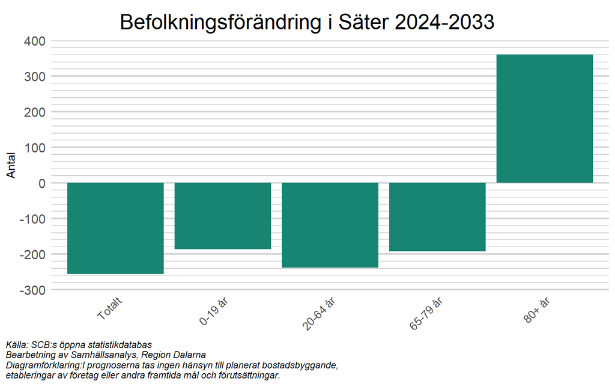